# Final Project

https://registry.opendata.aws/sentinel-2/

https://github.com/samx18/geospatial_analysis/blob/main/geospatial_analysis.ipynb

https://catalog.data.gov/dataset/monthly-provisional-counts-of-deaths-by-age-group-sex-and-race-ethnicity-for-select-causes

https://catalog.data.gov/dataset/conditions-contributing-to-deaths-involving-coronavirus-disease-2019-covid-19-by-age-group

# Analysis of Medical Conditions Contributing to COVID-19 Death by State

By Gordon Moss

## Part 1: Data Collection

First, we will import some libraries and load the CDC data into a Pandas DataFrame. Some of the data included by the CDC isn't necessary for this analysis, so we remove it from our working DataFrame for simplicity. Note that this dataset has data for New York City and Puerto Rico in addition to all 50 states.

```python
#!pip install plotly
```

```python
import numpy as np
import pandas as pd
import matplotlib.pyplot as plt
import seaborn as sns
import plotly.express as px
import statsmodels.formula.api as smf

from sklearn.linear_model import LinearRegression
from sklearn.neighbors import KNeighborsClassifier

from IPython.display import Image

# https://pythonfix.com/code/us-states-abbrev.py/
# used for compatibility with plotly
ABBREV = {
"Alabama": "AL",
"Alaska": "AK",
"Arizona": "AZ",
"Arkansas": "AR",
"California": "CA",
"Colorado": "CO",
"Connecticut": "CT",
"Delaware": "DE",
"Florida": "FL",
"Georgia": "GA",
"Hawaii": "HI",
"Idaho": "ID",
"Illinois": "IL",
"Indiana": "IN",
"Iowa": "IA",
"Kansas": "KS",
"Kentucky": "KY",
"Louisiana": "LA",
"Maine": "ME",
"Maryland": "MD",
"Massachusetts": "MA",
"Michigan": "MI",
"Minnesota": "MN",
"Mississippi": "MS",
"Missouri": "MO",
"Montana": "MT",
"Nebraska": "NE",
"Nevada": "NV",
"New Hampshire": "NH",
"New Jersey": "NJ",
"New Mexico": "NM",
"New York": "NY",
"North Carolina": "NC",
"North Dakota": "ND",
"Ohio": "OH",
"Oklahoma": "OK",
"Oregon": "OR",
"Pennsylvania": "PA",
"Rhode Island": "RI",
"South Carolina": "SC",
"South Dakota": "SD",
"Tennessee": "TN",
"Texas": "TX",
"Utah": "UT",
"Vermont": "VT",
"Virginia": "VA",
"Washington": "WA",
"West Virginia": "WV",
"Wisconsin": "WI",
"Wyoming": "WY",
"District of Columbia": "DC",
"American Samoa": "AS",
"Guam": "GU",
"Northern Mariana Islands": "MP",
"Puerto Rico": "PR",
"United States Minor Outlying Islands": "UM",
"U.S. Virgin Islands": "VI",
}
```

```python
# reading csv
df = pd.read_csv('Conditions_Contributing_to_COVID-19_Deaths__by_State_and_Age__Provisional_2020-2023.csv')

# removing unecessary data
df = df[df['Group'] == 'By Month']
df = df[(df['Age Group'] != 'All Ages') & (df['Age Group'] != 'Not stated')]
df = df[df['Condition'] != 'COVID-19']     # our analysis is concerned with medical conditions which
                                           # contribute to death by COVID-19, so we don't care about
                                           # people who died without contributions.

# merging "year" and "month" into one column
df['Year'] += (df['Month'] - 1) / 12

# deleting unecessary columns
del df['Group']
del df['Start Date']
del df['End Date']
del df['Data As Of']
del df['Flag']
del df['ICD10_codes']
del df['Number of Mentions']
del df['Month']

# removing unusable data
df.dropna(axis='index', inplace=True)
df = df[df['State'] != 'United States']  # different measurement techniques by CDC make this data
                                         # incompatible with state-specific data

df.head()
```

|  | Year | State | Condition Group | Condition | Age Group | COVID-19 Deaths |
| --- | --- | --- | --- | --- | --- | --- |
| 71530 | 2020.000000 | Alabama | Respiratory diseases | Influenza and pneumonia | 0-24 | 0.0 |
| 71531 | 2020.083333 | Alabama | Respiratory diseases | Influenza and pneumonia | 0-24 | 0.0 |
| 71532 | 2020.166667 | Alabama | Respiratory diseases | Influenza and pneumonia | 0-24 | 0.0 |
| 71533 | 2020.250000 | Alabama | Respiratory diseases | Influenza and pneumonia | 0-24 | 0.0 |
| 71534 | 2020.333333 | Alabama | Respiratory diseases | Influenza and pneumonia | 0-24 | 0.0 |

Next, we create a second DataFrame which contains the national values for COVID deaths. In this DataFrame, each row corresponds to the total number of COVID deaths associated with the given year, condition, and age group. This DataFrame will be useful for comparing data from individual states to the nation as a whole.

```python
newcols = ['Year', 'Condition Group', 'Condition', 'Age Group', 'COVID-19 Deaths']
natltotal = pd.DataFrame(columns=newcols)

for cols, data in df.groupby(['Year', 'Condition Group', 'Condition', 'Age Group']):
    new = pd.DataFrame({k:[v] for k,v in zip(newcols, list(cols) + [data['COVID-19 Deaths'].sum()])})
    natltotal = pd.concat([natltotal, new])

natltotal.head()
```

|  | Year | Condition Group | Condition | Age Group | COVID-19 Deaths |
| --- | --- | --- | --- | --- | --- |
| 0 | 2020.0 | All other conditions and causes (residual) | All other conditions and causes (residual) | 0-24 | 0.0 |
| 0 | 2020.0 | All other conditions and causes (residual) | All other conditions and causes (residual) | 25-34 | 0.0 |
| 0 | 2020.0 | All other conditions and causes (residual) | All other conditions and causes (residual) | 35-44 | 0.0 |
| 0 | 2020.0 | All other conditions and causes (residual) | All other conditions and causes (residual) | 45-54 | 0.0 |
| 0 | 2020.0 | All other conditions and causes (residual) | All other conditions and causes (residual) | 55-64 | 0.0 |

Finally, we create a third DataFrame which contains state-specific data on COVID deaths. In this DataFrame, each row corresponds to the total number of COVID deaths associated with the given state, condition, and age group. We choose to eliminate the "year" column due to the inconsistent reporting timelines across states, as will be seen in the exploratory analysis. Instead, we will base our analysis on the total number of COVID deaths from 2020-2023.

```python
newcols = ['State', 'Condition Group', 'Condition', 'Age Group', 'COVID-19 Deaths']
statetotal = pd.DataFrame(columns=newcols)

for tag, data in df.groupby(['State', 'Condition Group', 'Condition', 'Age Group']):
    new = pd.DataFrame({k:[v] for k,v in zip(newcols, list(tag) + [data['COVID-19 Deaths'].sum()])})
    statetotal = pd.concat([statetotal, new])

statetotal.head()
```

|  | State | Condition Group | Condition | Age Group | COVID-19 Deaths |
| --- | --- | --- | --- | --- | --- |
| 0 | Alabama | All other conditions and causes (residual) | All other conditions and causes (residual) | 0-24 | 0.0 |
| 0 | Alabama | All other conditions and causes (residual) | All other conditions and causes (residual) | 25-34 | 31.0 |
| 0 | Alabama | All other conditions and causes (residual) | All other conditions and causes (residual) | 35-44 | 121.0 |
| 0 | Alabama | All other conditions and causes (residual) | All other conditions and causes (residual) | 45-54 | 471.0 |
| 0 | Alabama | All other conditions and causes (residual) | All other conditions and causes (residual) | 55-64 | 1256.0 |

Finally, we will normalize our data. To do this, we divide the number of COVID deaths in each row by the total number of COVID deaths associated with the year, state, and age group of that particular row. For the national dataframe, we will just normalize by year and age range. For the state-specific dataframe, we will normalize by state and age-group. This will result in us having the percentage of each condition's contribution to the total COVID deaths for every combination of the other columns.

Then, we will calculate the difference between each condition's percentage and the corresponding national average percentage for the general and state-specific datasets.

```python
def normDeathsByCol(frame, col):
    # Adds a column to "frame" which represents the percent/100 of all covid deaths in
    # col(s) which are due to each row.

    new = pd.DataFrame()

    for tag, group in frame.groupby(col):
        total = group['COVID-19 Deaths'].sum()
        group['norm'] = group['COVID-19 Deaths'] / total if total != 0.0 else 0.0
        new = pd.concat([new, group])

    return new

def diffFromAvg(frame, total):
    # Adds a column to "frame" which represents the difference between the normalized deaths
    # of each row and the normalized deaths of the United States for that year,condition, and
    # age group.

    total = total.copy()
    total['diff'] = total['norm']
    frame = frame.merge(total, how='right', on=['Year', 'Condition Group', 'Condition', 'Age Group'])
    del frame['COVID-19 Deaths_y']
    del frame['norm_y']
    frame = frame.rename(columns={'COVID-19 Deaths_x':'COVID-19 Deaths', 'norm_x':'norm'})
    frame['diff'] = frame['norm'] - frame['diff']
    return frame

df = normDeathsByCol(df, ['Year', 'State', 'Age Group'])
natltotal = normDeathsByCol(natltotal, ['Year', 'Age Group'])
statetotal = normDeathsByCol(statetotal, ['State', 'Age Group'])
df = diffFromAvg(df, natltotal)
df.head()
```

|  | Year | State | Condition Group | Condition | Age Group | COVID-19 Deaths | norm | diff |
| --- | --- | --- | --- | --- | --- | --- | --- | --- |
| 0 | 2020.0 | Alabama | All other conditions and causes (residual) | All other conditions and causes (residual) | 0-24 | 0.0 | 0.0 | 0.0 |
| 1 | 2020.0 | Alaska | All other conditions and causes (residual) | All other conditions and causes (residual) | 0-24 | 0.0 | 0.0 | 0.0 |
| 2 | 2020.0 | Arizona | All other conditions and causes (residual) | All other conditions and causes (residual) | 0-24 | 0.0 | 0.0 | 0.0 |
| 3 | 2020.0 | Arkansas | All other conditions and causes (residual) | All other conditions and causes (residual) | 0-24 | 0.0 | 0.0 | 0.0 |
| 4 | 2020.0 | California | All other conditions and causes (residual) | All other conditions and causes (residual) | 0-24 | 0.0 | 0.0 | 0.0 |

```python
# national COVID deaths by condition and age group, used for calculating diff for statetotal
newcols = ['Condition Group', 'Condition', 'Age Group', 'COVID-19 Deaths']
natltotal2 = pd.DataFrame(columns=newcols)

for tag, data in natltotal.groupby(['Condition Group', 'Condition', 'Age Group']):
    vals = list(tag) + [data['COVID-19 Deaths'].sum()]
    natltotal2 = pd.concat([natltotal2, pd.DataFrame({k:[v] for k,v in zip(newcols, vals)})])

natltotal2 = normDeathsByCol(natltotal2, 'Age Group')
natltotal2.head()
```

|  | Condition Group | Condition | Age Group | COVID-19 Deaths | norm |
| --- | --- | --- | --- | --- | --- |
| 0 | All other conditions and causes (residual) | All other conditions and causes (residual) | 0-24 | 496.0 | 0.412989 |
| 0 | Alzheimer disease | Alzheimer disease | 0-24 | 0.0 | 0.000000 |
| 0 | Circulatory diseases | Cardiac arrest | 0-24 | 22.0 | 0.018318 |
| 0 | Circulatory diseases | Cardiac arrhythmia | 0-24 | 0.0 | 0.000000 |
| 0 | Circulatory diseases | Cerebrovascular diseases | 0-24 | 0.0 | 0.000000 |

```python
statetotal = statetotal.merge(natltotal2, how='right', on=['Condition Group', 'Condition', 'Age Group'])

del statetotal['COVID-19 Deaths_y']
statetotal = statetotal.rename(columns={'COVID-19 Deaths_x':'COVID-19 Deaths', 'norm_x':'norm', 'norm_y':'diff'})
statetotal['diff'] = statetotal['norm'] - statetotal['diff']

statetotal.head()
```

|  | State | Condition Group | Condition | Age Group | COVID-19 Deaths | norm | diff |
| --- | --- | --- | --- | --- | --- | --- | --- |
| 0 | Alabama | All other conditions and causes (residual) | All other conditions and causes (residual) | 0-24 | 0.0 | 0.000000 | -0.412989 |
| 1 | Alaska | All other conditions and causes (residual) | All other conditions and causes (residual) | 0-24 | 0.0 | 0.000000 | -0.412989 |
| 2 | Arizona | All other conditions and causes (residual) | All other conditions and causes (residual) | 0-24 | 0.0 | 0.000000 | -0.412989 |
| 3 | Arkansas | All other conditions and causes (residual) | All other conditions and causes (residual) | 0-24 | 0.0 | 0.000000 | -0.412989 |
| 4 | California | All other conditions and causes (residual) | All other conditions and causes (residual) | 0-24 | 119.0 | 0.420495 | 0.007506 |

## Part 2: Exploratory Analysis

Now that our primary dataframes are prepared, we can do some exploratory data analysis using the matplotlib and seaborn libraries.

First, let's look at the time evolution of condition prevalences among COVID deaths for different age groups.

Due to differences in data reporting timelines from state to state, the raw data is often "jumpy" from month to month. To visually correct for this "jumpiness" in the plots, we will plot the 6-month rolling average for each condition.

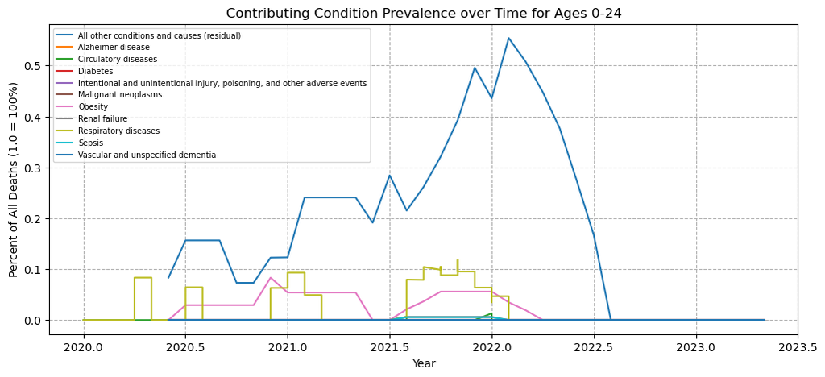

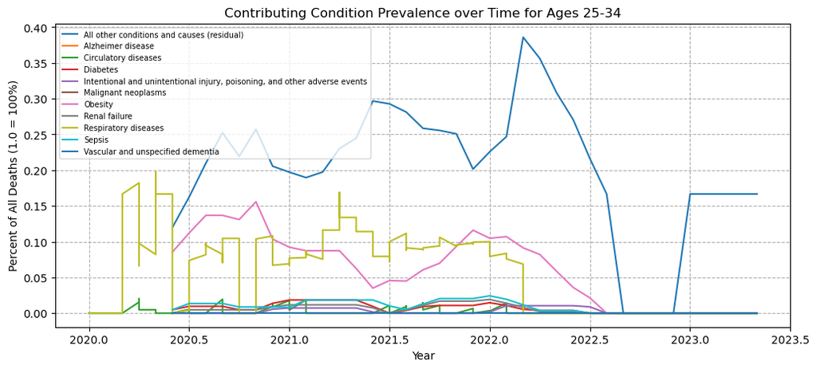

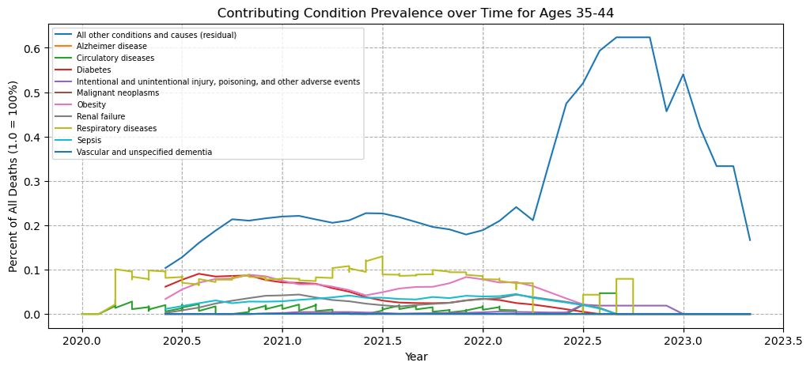

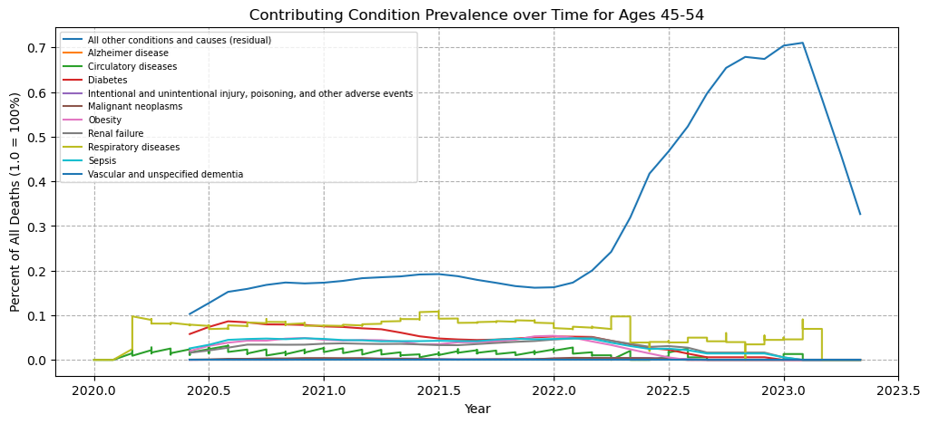

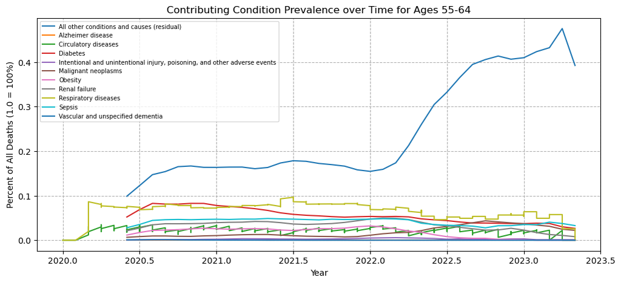

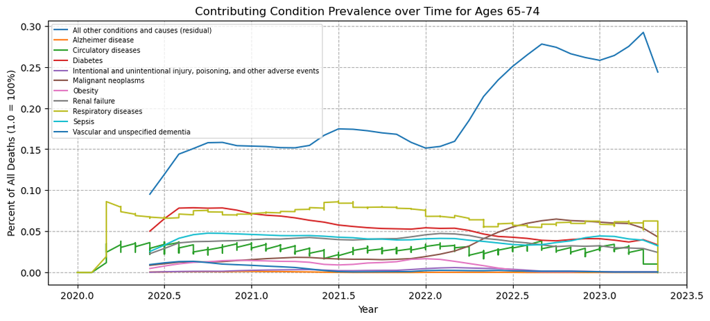

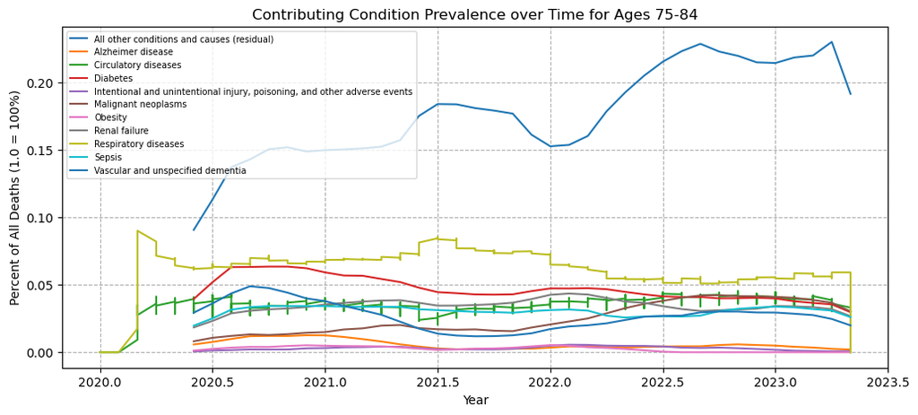

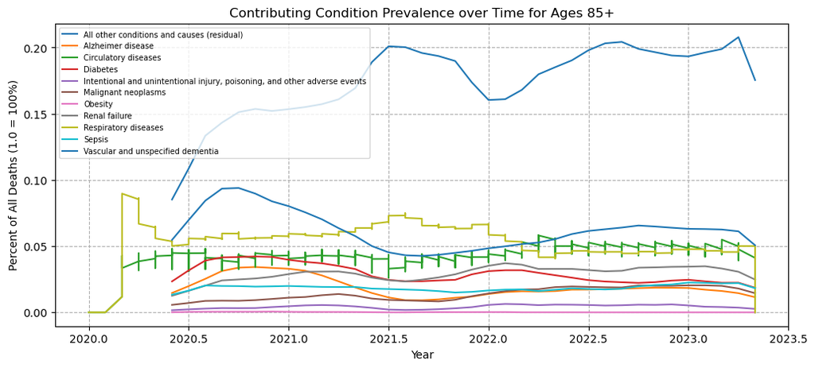

```python
rolling_avg_size = 6    # number of months included in the rolling average

for age, d1 in natltotal.groupby('Age Group'):
    plt.figure(figsize=(12, 5))
    plt.title(f'Contributing Condition Prevalence over Time for Ages {age}')
    plt.xlabel('Year')
    plt.ylabel('Percent of All Deaths (1.0 = 100%)')

    for cnd, d2 in d1.groupby('Condition Group'):
        if cnd in ['COVID-19']:
            continue

        plt.plot(d2['Year'], d2['norm'].rolling(rolling_avg_size).mean(), label=f'{cnd}')

    plt.legend(prop={'size':7})
    plt.grid(linestyle='--')
    plt.show()
```

As we can see, various health conditions become increasingly associated with death due to COVID-19 in older age groups.

Next, we will look at the state-specific normalized deviations from the national averages for various conditions, which we previously calculated.

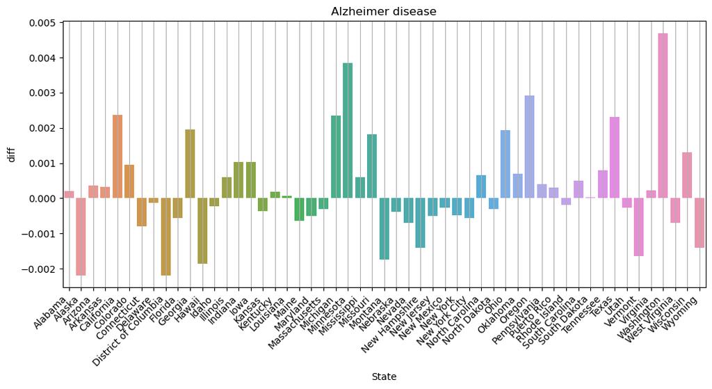

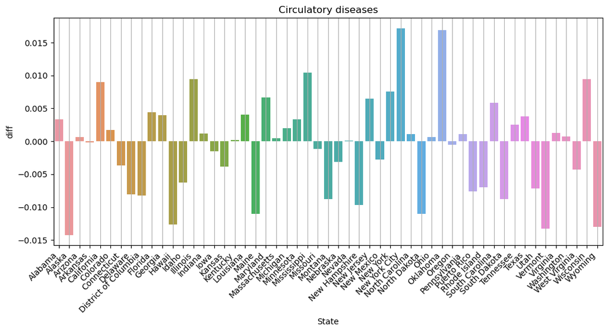

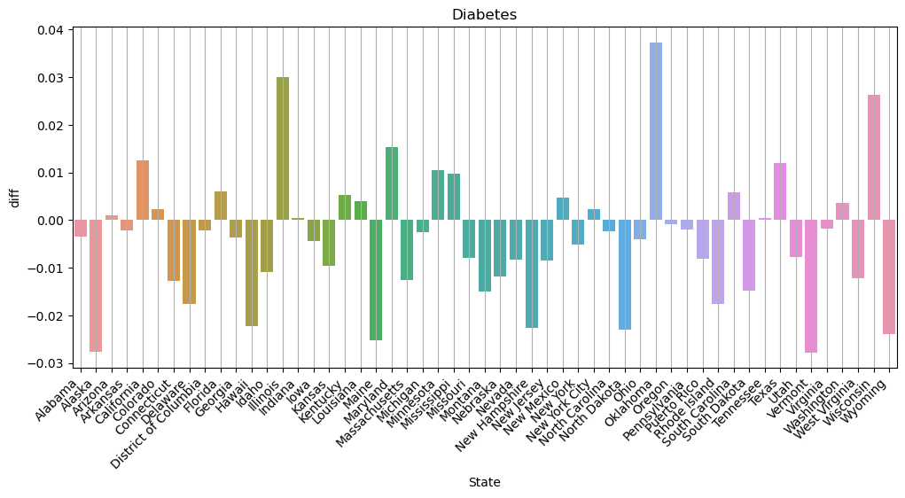

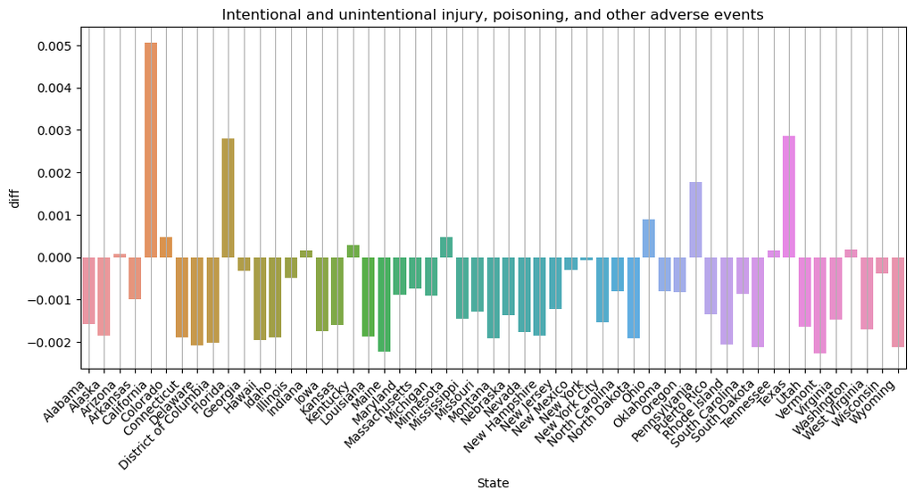

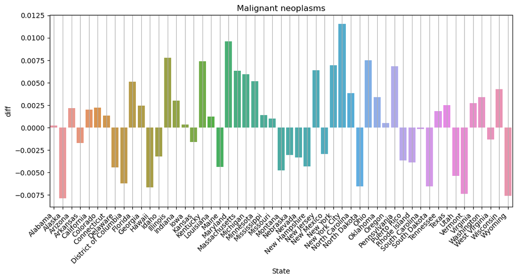

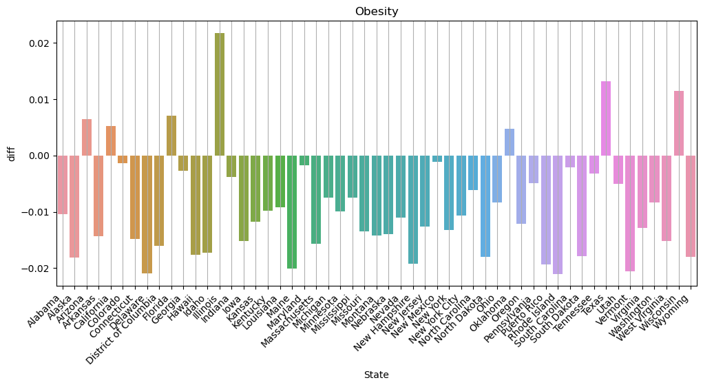

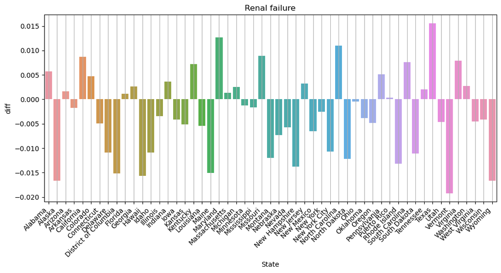

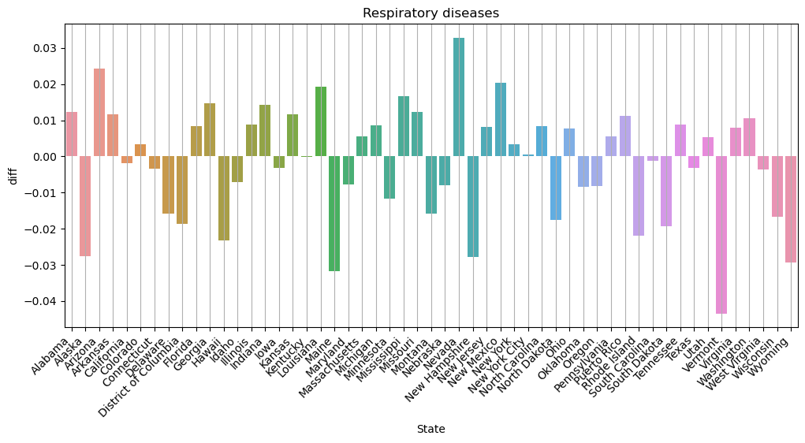

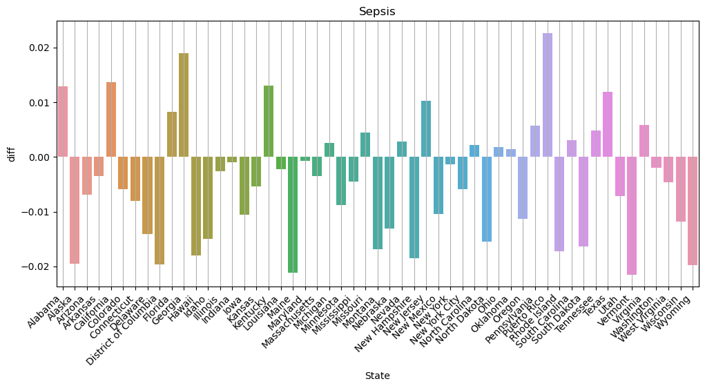

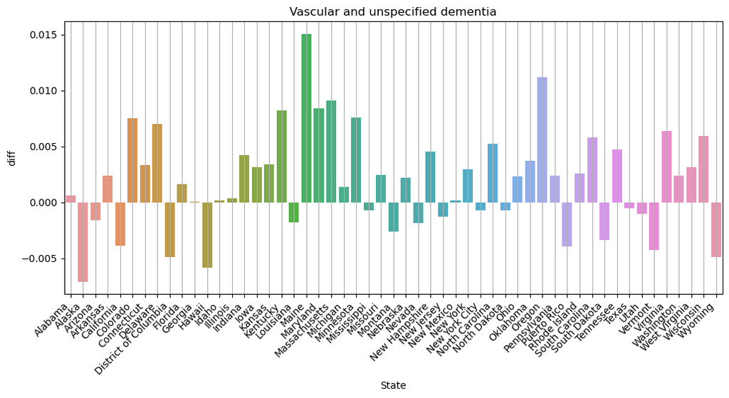

```python
for cnd, d1 in df.groupby('Condition Group'):
    if cnd in ['All other conditions and causes (residual)', 'COVID-19']:
        continue

    plt.figure(figsize=(12, 5))
    plt.title(cnd)
    data = pd.DataFrame(columns=['State', 'diff'])

    for state, d2 in d1.groupby('State'):
        if state == 'United States':
            continue
        new = pd.DataFrame({'State': [state], 'diff': [d2['diff'].mean()]})
        data = pd.concat([data, new], ignore_index=True)

    bar = sns.barplot(data=data, x='State', y='diff')
    bar.set_xticklabels(bar.get_xticklabels(), rotation=45, ha="right")
    plt.gca().yaxis.grid(False)
    plt.gca().xaxis.grid(True)

    plt.show()
```

To better visualise this information, lets draw a map of the US, and label each state with its deadliest condition (relative to the average).

The simplest way to do this is by creating a new DataFrame:

```python
unique = df['State'].unique()
max_diff = pd.DataFrame(index=unique, columns=['Condition Group', 'Condition', 'diff'])
max_diff['diff'] = np.ones([len(unique), 1]) * -np.inf

for tag, data in statetotal.groupby(['State', 'Condition Group', 'Condition']):
    state, cg, c = tag
    mean_diff = data['diff'].mean()

    if max_diff.loc[state]['diff'] < mean_diff:
        max_diff.loc[state, 'Condition Group'] = cg
        max_diff.loc[state, 'Condition'] = c
        max_diff.loc[state, 'diff'] = mean_diff

max_diff['State'] = max_diff.index.map(ABBREV)
max_diff.head()
```

|  | Condition Group | Condition | diff | State |
| --- | --- | --- | --- | --- |
| Alabama | Respiratory diseases | Respiratory failure | 0.030192 | AL |
| Alaska | Respiratory diseases | Influenza and pneumonia | 0.094763 | AK |
| Arizona | Respiratory diseases | Adult respiratory distress syndrome | 0.017797 | AZ |
| Arkansas | Respiratory diseases | Respiratory failure | 0.063636 | AR |
| California | Circulatory diseases | Cardiac arrest | 0.042862 | CA |

Usind this DataFrame alongside the "plotly" library, making the plots becomes trivial: (see https://plotly.github.io/plotly.py-docs/generated/plotly.express.choropleth.html for details)

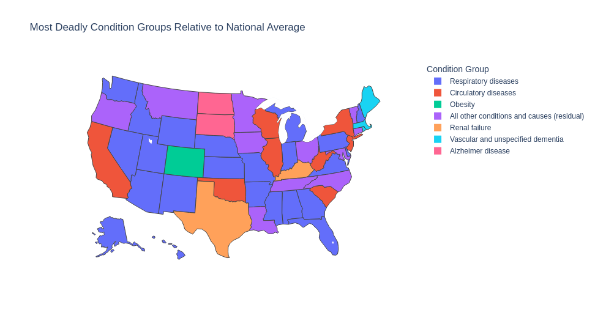

```python
fig = px.choropleth(max_diff, locationmode="USA-states", color='Condition Group', locations='State',
                   scope='usa', title='Most Deadly Condition Groups Relative to National Average')

#fig.show()
# showing saved image because plotly plots don't display in HTML
Image(filename = "fig1.png")
```

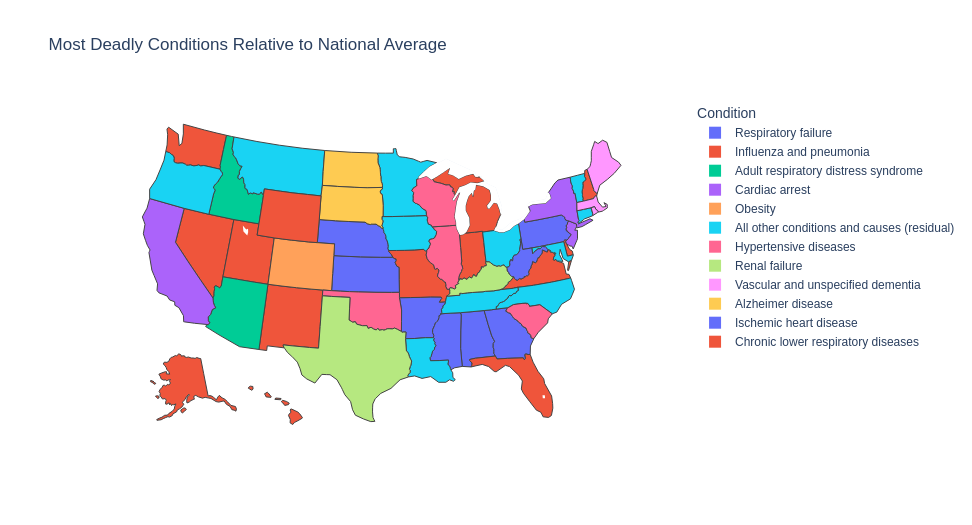

```python
fig = px.choropleth(max_diff, locationmode="USA-states", color='Condition', locations='State',
                   scope='usa', title='Most Deadly Conditions Relative to National Average')

#fig.show()
# showing saved image because plotly plots don't display in HTML
Image(filename = "fig2.png")
```

## Part 3: Hypothesis Testing

```python
statetotal.head()
```

|  | State | Condition Group | Condition | Age Group | COVID-19 Deaths | norm | diff |
| --- | --- | --- | --- | --- | --- | --- | --- |
| 0 | Alabama | All other conditions and causes (residual) | All other conditions and causes (residual) | 0-24 | 0.0 | 0.000000 | -0.412989 |
| 1 | Alaska | All other conditions and causes (residual) | All other conditions and causes (residual) | 0-24 | 0.0 | 0.000000 | -0.412989 |
| 2 | Arizona | All other conditions and causes (residual) | All other conditions and causes (residual) | 0-24 | 0.0 | 0.000000 | -0.412989 |
| 3 | Arkansas | All other conditions and causes (residual) | All other conditions and causes (residual) | 0-24 | 0.0 | 0.000000 | -0.412989 |
| 4 | California | All other conditions and causes (residual) | All other conditions and causes (residual) | 0-24 | 119.0 | 0.420495 | 0.007506 |